# Macrofauna Respiration

Chih-Lin Wei

2023-02-26

```r
library(bbbs)
library(BenthicPro)
library(ggplot2)
library(plyr)
library(doBy)
library(readxl)
library(knitr)
library(nlme)

large <- theme(legend.title = element_text(size=20),
        legend.text = element_text(size=20),
        axis.title = element_text(size=20),
        axis.text = element_text(size=20))
rotate <- theme(axis.text.x = element_text(size=20, angle=60, hjust=0.5))

# dark theme for ggplot
dark <- theme(plot.background = element_rect(colour = 'NA', fill = 'gray10'),
        panel.background = element_rect(colour = 'NA', fill = 'transparent'),
        legend.background = element_rect(colour = 'NA', fill = 'transparent'),
        legend.title = element_text(colour = 'white', size=20),
        legend.text = element_text(colour = 'white', size=20),
        axis.title = element_text(colour = 'white', size=20),
        axis.text = element_text(colour = 'white', size=20),
        axis.ticks = element_line(colour = 'white'),
        panel.border = element_rect(fill = 'NA', colour = 'white'),
        panel.grid.major = element_line(colour = 'gray30'),
        panel.grid.minor = element_line(colour = 'gray20'))
```

# 1 Data preparation

Mass-specific macrofauna respiration rate was estimated from body mass and temperature using an empirical model, $log(R/M) = 8.3732 - 0.2073 * log(M) - 2766.0235 / T$, based on a large database compilated for aquatic invertebrate respriation (<22000 measurements, >900 species, > 440 references) by [Thomas Brey](http://www.thomas-brey.de/science/virtualhandbook/respir/rempirics1.html). In the equation, R/M is the mass-specific respiration (J/J/day), M is individual body mass (J), and T is water temperature (K).

```r
dat <- subset(mac, Cruise=="OR1_1096"|Cruise=="OR1_1102"|Cruise=="OR1_1114"|Cruise=="OR1_1126"|Cruise=="OR1_1128"|Cruise=="OR1_1132")
dat.sum <- summaryBy(Wt~Habitat+Cruise+Station+Deployment+Tube+Taxon, data=dat, FUN=c(sum, length))
names(dat.sum)[-1:-6] <- c("Wt", "Count")
dat.sum$Sample.area <- mac$Area[match(with(dat.sum, paste(Cruise, Station)), with(mac, paste(Cruise, Station)))]

# Convert the numbers of polychaete specimen (with head) to abundance
pols <- subset(mac, Taxon=="Polychaeta" & (Condition=="FH" | Condition=="C" | Condition=="FHT"))
pola <- summaryBy(Wt~Habitat+Cruise+Station+Deployment+Tube+Taxon, data=pols, FUN=length, var.names="Count", keep.names = T)
keep <- match(with(pola, paste(Cruise, Station, Deployment, Tube, Taxon)), with(dat.sum, paste(Cruise, Station, Deployment, Tube, Taxon)))
dat.sum$Count[keep] <- pola$Count

# Convert the numbers of complete ophiroid specimens to abundance
ophs <- subset(mac, Taxon=="Ophiuroidea" & Condition=="C")
opha <- summaryBy(Wt~Habitat+Cruise+Station+Deployment+Tube+Taxon, data=ophs, FUN=length, var.names="Count", keep.names = T)
keep <- match(with(opha, paste(Cruise, Station, Deployment, Tube, Taxon)), with(dat.sum, paste(Cruise, Station, Deployment, Tube, Taxon)))
dat.sum$Count[keep] <- opha$Count

# Remove Cyclopoida and Calanoida
dat.sum <- subset(dat.sum, !(Taxon=="Cyclopoida"|Taxon=="Calanoida"))

# Match to marofauna respiration parameters
dat.sum <- cbind(dat.sum, mpr[match(dat.sum$Taxon, mpr$Taxon), c("ConFac_j2mgwm", "ConFac_j2mgc")])
dat.sum$Bodymass <- with(dat.sum, Wt*ConFac_j2mgwm/Count)
dat.sum <- cbind(dat.sum, env[match(with(dat.sum, paste(Cruise, Station)), with(env, paste(Cruise, Station))), c("Temperature", "Depth")])
dat.sum <- cbind(dat.sum, mpr[match(dat.sum$Taxon, mpr$Taxon), c(-1:-3, -21)])

# Calculate R/M ratio
# Convert bodymass in J to kcal
individualRM <- 8.3732-0.2073*log10(dat.sum$Bodymass)-2766.0235 /(dat.sum$Temperature+273.15)

RMresults<-cbind(dat.sum, daily.RtoM=10^individualRM)

# Daily respiration in mg WM per species and sample per square meter
RMresults$respirationW <- with(RMresults, daily.RtoM*Wt/Sample.area)

# Daily respiration in J per species and sample per square meter
RMresults$respirationJ <- with(RMresults, respirationW*ConFac_j2mgwm)

# Daily respiration in milligram carbon per species and sample per square meter
RMresults$respirationC <- with(RMresults, respirationJ/ConFac_j2mgc)


# Average P/B ratio by tube
p2b <- summaryBy(Depth+daily.RtoM~Habitat+Cruise+Station+Deployment+Tube, data = RMresults, fun = mean, keep.names = TRUE)

# Summation production by tube
pd <- summaryBy(respirationW+respirationJ+respirationC+Count+Wt~Habitat+Cruise+Station+Deployment+Tube, data = RMresults, fun = sum, keep.names = TRUE)
pd <- cbind(p2b, pd[, -1:-5])

se <- function(x) sd(x)/length(x)^0.5
out <- summaryBy(Depth+daily.RtoM+respirationW+respirationJ+respirationC~Habitat+Cruise+Station, data = pd, FUN = c(mean, sd, length, se))

out <- out[, c("Habitat", "Cruise", "Station", "Depth.mean", "daily.RtoM.mean", "daily.RtoM.se", "respirationW.mean", "respirationW.se", "respirationJ.mean", "respirationJ.se", "respirationC.mean", "respirationC.se", "Depth.length")]

names(out) <- c("Habitat", "Cruise", "Station", "Depth", "daily.RtoM", "daily.RtoM.se", "respirationW", "respirationW.se", "respirationJ", "respirationJ.se", "respirationC", "respirationC.se", "n")

kable(out)
```

| Habitat | Cruise | Station | Depth | daily.RtoM | daily.RtoM.se | respirationW | respirationW.se | respirationJ | respirationJ.se | respirationC | respirationC.se | n |
| --- | --- | --- | --- | --- | --- | --- | --- | --- | --- | --- | --- | --- |
| Canyon | OR1_1096 | GC1 | 222.000 | 0.0738798 | 0.0058311 | 4.7285816 | 1.9379091 | 33.986207 | 18.9675818 | 0.7529728 | 0.4189823 | 3 |
| Canyon | OR1_1096 | GC2 | 462.000 | 0.0607794 | 0.0126934 | 5.5016162 | 2.5180234 | 19.479252 | 8.7425633 | 0.4247000 | 0.1924017 | 3 |
| Canyon | OR1_1096 | GC3 | 655.000 | 0.0552180 | 0.0022313 | 5.7893699 | 1.6921471 | 20.395956 | 5.9614359 | 0.4463010 | 0.1304472 | 3 |
| Canyon | OR1_1102 | GC1 | 323.000 | 0.0696004 | NA | 4.1983590 | NA | 14.790823 | NA | 0.3236504 | NA | 1 |
| Canyon | OR1_1102 | GC2 | 482.000 | 0.0653531 | 0.0075179 | 0.7043136 | 0.3122335 | 2.960268 | 0.8212243 | 0.0673783 | 0.0171257 | 3 |
| Canyon | OR1_1102 | GC3 | 653.000 | 0.0448761 | 0.0064332 | 4.6921775 | 1.8612086 | 18.288442 | 8.1027117 | 0.4174041 | 0.1836175 | 3 |
| Canyon | OR1_1102 | GC4 | 1065.200 | 0.0362141 | 0.0002337 | 1.5110046 | 0.4035004 | 9.812575 | 2.6754822 | 0.2340717 | 0.0665888 | 3 |
| Canyon | OR1_1114 | GC1 | 319.750 | 0.0939354 | 0.0202939 | 1.5412518 | 0.3899786 | 4.984261 | 1.2412916 | 0.1090357 | 0.0271902 | 5 |
| Canyon | OR1_1114 | GC2 | 478.000 | 0.0610101 | 0.0035673 | 2.8378016 | 0.4004459 | 10.721126 | 1.4766091 | 0.2375614 | 0.0332378 | 4 |
| Canyon | OR1_1114 | GC3 | 654.750 | 0.0559817 | 0.0044393 | 1.8178061 | 0.3418632 | 11.176891 | 2.0117585 | 0.2730876 | 0.0503850 | 4 |
| Canyon | OR1_1114 | GC4 | 1051.000 | 0.0399738 | 0.0043943 | 6.0149719 | 4.9014175 | 22.450505 | 17.5868017 | 0.4977079 | 0.3866665 | 6 |
| Canyon | OR1_1126 | GC1 | 318.000 | 0.0786333 | 0.0068375 | 0.8484716 | 0.1396229 | 2.850050 | 0.4780108 | 0.0623643 | 0.0104598 | 5 |
| Canyon | OR1_1126 | GC3 | 655.000 | 0.0403055 | 0.0013025 | 4.6783024 | 4.0928259 | 17.876182 | 13.7398300 | 0.3997133 | 0.2973158 | 2 |
| Canyon | OR1_1126 | GC4 | 1067.667 | 0.0342309 | 0.0019644 | 0.8255355 | 0.2139897 | 4.927399 | 1.0224412 | 0.1189771 | 0.0240745 | 4 |
| Slope | OR1_1096 | GS1 | 270.000 | 0.0821413 | 0.0055007 | 6.9323151 | 3.1069906 | 30.836589 | 15.1393743 | 0.6522409 | 0.3309474 | 3 |
| Slope | OR1_1096 | GS2 | 465.000 | 0.0605900 | 0.0029971 | 5.0763223 | 1.8158034 | 21.371195 | 6.1155982 | 0.4750949 | 0.1292336 | 3 |
| Slope | OR1_1096 | GS3 | 692.000 | 0.0428921 | 0.0023813 | 3.4256594 | 0.6944932 | 16.558172 | 7.7559340 | 0.3669387 | 0.1746597 | 3 |
| Slope | OR1_1102 | GS1 | 278.670 | 0.0850686 | 0.0015968 | 69.8070043 | 40.0138154 | 247.172467 | 140.7605120 | 5.4170532 | 3.0783299 | 3 |
| Slope | OR1_1102 | GS2 | 463.540 | 0.0614318 | 0.0030338 | 11.6426930 | 8.1150169 | 43.296876 | 29.9266943 | 0.9627268 | 0.6610267 | 3 |
| Slope | OR1_1102 | GS3 | 682.000 | 0.0457338 | 0.0023399 | 2.4691887 | 0.7642743 | 9.601063 | 2.5811180 | 0.2152603 | 0.0560573 | 4 |
| Slope | OR1_1114 | GS1 | 279.000 | 0.0816368 | 0.0024461 | 29.4940489 | 20.0236639 | 99.754949 | 62.2145885 | 2.2406466 | 1.4163267 | 4 |
| Slope | OR1_1114 | GS2 | 462.000 | 0.0633021 | 0.0058133 | 11.0628885 | 5.8305363 | 40.301504 | 20.4740363 | 0.8938265 | 0.4537895 | 5 |
| Slope | OR1_1114 | GS3 | 690.000 | 0.0451308 | 0.0023230 | 3.1257404 | 0.5154163 | 13.046297 | 2.9153207 | 0.2909517 | 0.0633924 | 4 |
| Slope | OR1_1114 | GS4 | 848.000 | 0.0401132 | 0.0007868 | 4.3331116 | 0.6611768 | 15.163165 | 2.2798108 | 0.3389331 | 0.0478303 | 4 |
| Slope | OR1_1126 | GS1 | 277.000 | 0.0761642 | 0.0034706 | 10.1986444 | 1.6045642 | 39.590699 | 6.5664514 | 0.8727451 | 0.1435937 | 4 |
| Slope | OR1_1126 | GS2 | 463.000 | 0.0535380 | 0.0019272 | 4.4429157 | 0.5886368 | 16.080076 | 1.9071839 | 0.3622911 | 0.0429508 | 4 |
| Slope | OR1_1126 | GS3 | 690.000 | 0.0415941 | 0.0009603 | 3.8284218 | 0.5227065 | 13.517662 | 1.9894300 | 0.3002802 | 0.0447675 | 4 |
| Slope | OR1_1126 | GS4 | 848.000 | 0.0376444 | 0.0004810 | 2.9624938 | 0.7596944 | 10.553167 | 2.5735406 | 0.2374860 | 0.0574716 | 4 |

# 2 Mass-specific respiration rate

## 2.1 Linear regression with depth

```r
splitBy(~Habitat, out) %>% lapply(FUN=function(x)lm(daily.RtoM~Depth, data=x) %>% summary)
```

```
## $Canyon
##
## Call:
## lm(formula = daily.RtoM ~ Depth, data = x)
##
## Residuals:
##        Min         1Q     Median         3Q        Max
## -0.0146088 -0.0041563  0.0006788  0.0029640  0.0209373
##
## Coefficients:
##               Estimate Std. Error t value Pr(>|t|)
## (Intercept)  9.025e-02  5.539e-03  16.293  1.5e-09 ***
## Depth       -5.394e-05  8.375e-06  -6.441  3.2e-05 ***
## ---
## Signif. codes:  0 '***' 0.001 '**' 0.01 '*' 0.05 '.' 0.1 ' ' 1
##
## Residual standard error: 0.008687 on 12 degrees of freedom
## Multiple R-squared:  0.7756, Adjusted R-squared:  0.7569
## F-statistic: 41.48 on 1 and 12 DF,  p-value: 3.203e-05
##
##
## $Slope
##
## Call:
## lm(formula = daily.RtoM ~ Depth, data = x)
##
## Residuals:
##        Min         1Q     Median         3Q        Max
## -0.0099907 -0.0025619 -0.0006599  0.0036712  0.0071270
##
## Coefficients:
##               Estimate Std. Error t value Pr(>|t|)
## (Intercept)  9.973e-02  3.607e-03   27.65 3.09e-12 ***
## Depth       -7.819e-05  6.362e-06  -12.29 3.71e-08 ***
## ---
## Signif. codes:  0 '***' 0.001 '**' 0.01 '*' 0.05 '.' 0.1 ' ' 1
##
## Residual standard error: 0.004838 on 12 degrees of freedom
## Multiple R-squared:  0.9264, Adjusted R-squared:  0.9203
## F-statistic:   151 on 1 and 12 DF,  p-value: 3.706e-08
```

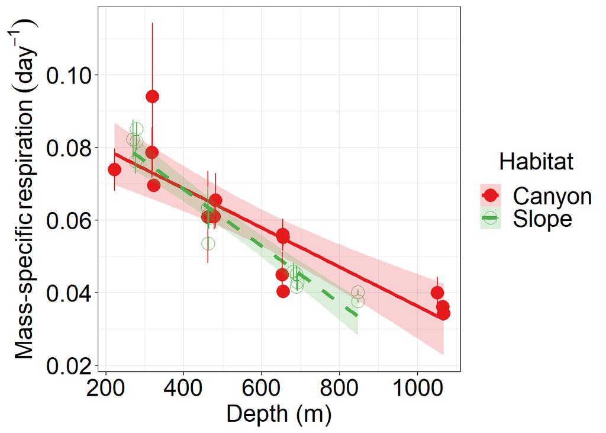

```r
(f5b <- ggplot(data=out,
       aes(x=Depth, y=daily.RtoM,
           ymin=daily.RtoM-daily.RtoM.se, ymax=daily.RtoM+daily.RtoM.se,
           shape=Habitat, colour=Habitat, fill=Habitat, linetype=Habitat))+
  geom_point(size=5, position="jitter")+
  stat_smooth(method="lm", formula=y~x, alpha=0.2, size=1.5)+
  geom_errorbar(linetype=1, position="jitter")+
  scale_colour_manual(values=c("#e41a1c", "#4daf4a"))+
  scale_fill_manual(values=c("#e41a1c", "#4daf4a"))+
  scale_linetype_manual(values=c(1,2))+
  scale_shape_manual(values=c(19,1))+
  labs(x="Depth (m)", y=expression("Mass-specific"~respiration~(day^-1)))+
  theme_bw() %+replace% large #%+replace% dark
)
```

```r
save(f5b, file="../rds/f5b.rds")
```

Mass-specific respiration rate declined significantly with depth in the canyon and on the slope.

## 2.2 Generalized Least Squares (GLS) modeling

#### 2.2.0.1 Main test

```r
f <- gls(daily.RtoM ~ Habitat+Depth+Cruise+Habitat:Depth+Habitat:Cruise+Depth:Cruise, data=out, method = "REML")
kable(summary(f)$tTable)
```

|  | Value | Std.Error | t-value | p-value |
| --- | --- | --- | --- | --- |
| (Intercept) | 0.0885555 | 0.0095879 | 9.2361929 | 0.0000001 |
| HabitatSlope | 0.0108201 | 0.0087552 | 1.2358417 | 0.2355222 |
| Depth | -0.0000566 | 0.0000190 | -2.9715761 | 0.0095071 |
| CruiseOR1_1102 | -0.0011904 | 0.0126575 | -0.0940464 | 0.9263170 |
| CruiseOR1_1114 | 0.0115210 | 0.0120895 | 0.9529742 | 0.3557085 |
| CruiseOR1_1126 | -0.0020849 | 0.0127210 | -0.1638941 | 0.8720025 |
| HabitatSlope:Depth | -0.0000222 | 0.0000132 | -1.6850345 | 0.1126675 |
| HabitatSlope:CruiseOR1_1102 | 0.0015520 | 0.0088341 | 0.1756883 | 0.8628886 |
| HabitatSlope:CruiseOR1_1114 | -0.0066791 | 0.0085079 | -0.7850511 | 0.4446468 |
| HabitatSlope:CruiseOR1_1126 | -0.0027416 | 0.0089193 | -0.3073810 | 0.7627798 |
| Depth:CruiseOR1_1102 | 0.0000037 | 0.0000221 | 0.1688241 | 0.8681905 |
| Depth:CruiseOR1_1114 | -0.0000031 | 0.0000211 | -0.1459011 | 0.8859421 |
| Depth:CruiseOR1_1126 | 0.0000045 | 0.0000212 | 0.2144443 | 0.8330886 |

```r
kable(anova(f))
```

|  | numDF | F-value | p-value |
| --- | --- | --- | --- |
| (Intercept) | 1 | 1603.6468696 | 0.0000000 |
| Habitat | 1 | 0.0295976 | 0.8657060 |
| Depth | 1 | 109.3284263 | 0.0000000 |
| Cruise | 3 | 1.2187391 | 0.3371911 |
| Habitat:Depth | 1 | 3.9015879 | 0.0669384 |
| Habitat:Cruise | 3 | 0.3455082 | 0.7928790 |
| Depth:Cruise | 3 | 0.0946549 | 0.9618199 |

Significant depth effects.

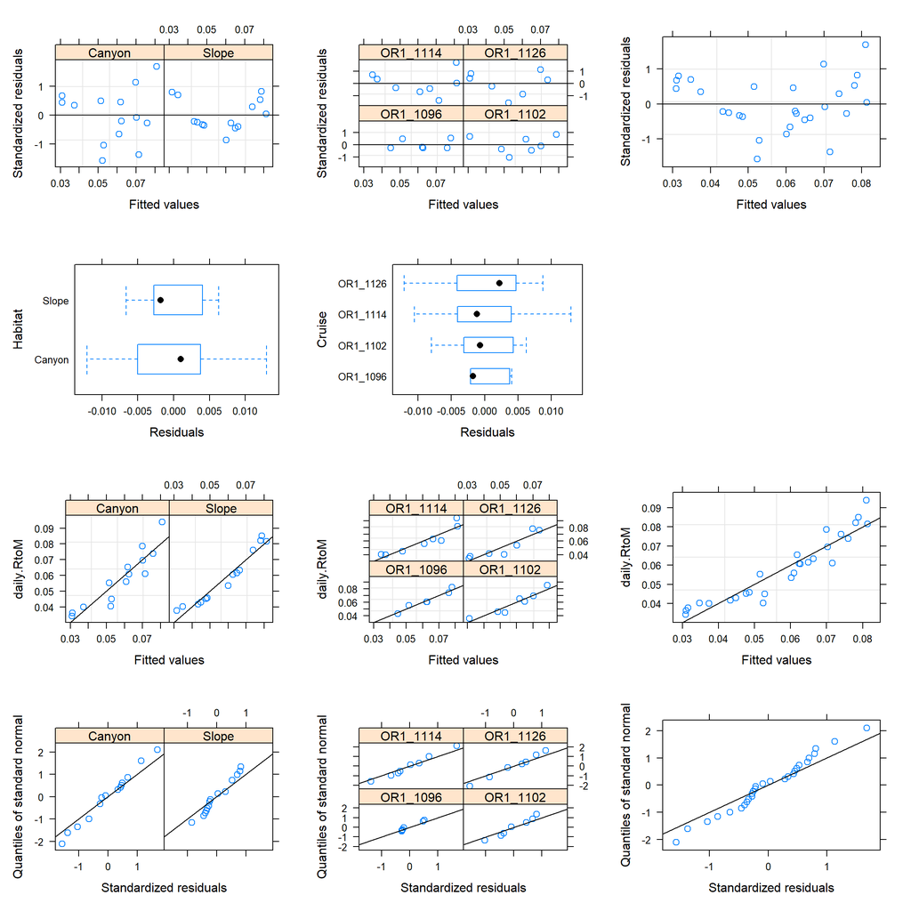

```r
# Function to plot dianotics plot
dianostic_plot <-
  function(f, y){
    # standardized residuals versus fitted values
    a1 <- plot(f, resid(., type = "p") ~ fitted(.) | Habitat, abline = 0)
    a2 <- plot(f, resid(., type = "p") ~ fitted(.) | Cruise, abline = 0)
    a3 <- plot(f, resid(., type = "p") ~ fitted(.), abline = 0)
    # box-plots of residuals
    b1<-plot(f, Habitat ~ resid(.))
    b2 <- plot(f, Cruise ~ resid(.))
    # observed versus fitted values
    c1<-plot(f, paste(paste(y, "fitted(.)", sep="~"), "Habitat", sep="|") %>% formula, abline = c(0,1))
    c2<-plot(f, paste(paste(y, "fitted(.)", sep="~"), "Cruise", sep="|") %>% formula, abline = c(0,1))
    c3<-plot(f, paste(y, "fitted(.)", sep="~") %>% formula, abline = c(0,1))
    # QQ plot
    d1<-qqnorm(f, ~ resid(., type = "p") | Habitat, abline = c(0,1))
    d2<-qqnorm(f, ~ resid(., type = "p") | Cruise, abline = c(0,1))
    d3<-qqnorm(f, ~ resid(., type = "p"), abline = c(0,1))

    print(a1, split=c(1,1,3,4), more=TRUE)
    print(a2, split=c(2,1,3,4), more=TRUE)
    print(a3, split=c(3,1,3,4), more=TRUE)
    print(b1, split=c(1,2,3,4), more=TRUE)
    print(b2, split=c(2,2,3,4), more=TRUE)
    #
    print(c1, split=c(1,3,3,4), more=TRUE)
    print(c2, split=c(2,3,3,4), more=TRUE)
    print(c3, split=c(3,3,3,4), more=TRUE)
    print(d1, split=c(1,4,3,4), more=TRUE)
    print(d2, split=c(2,4,3,4), more=TRUE)
    print(d3, split=c(3,4,3,4))
    }

dianostic_plot(f, y = "daily.RtoM")
```

# 3 Daily respiration in wet weight per square meter

## 3.1 Linear regression with depth

```r
splitBy(~Habitat, out) %>% lapply(FUN=function(x)lm(log10(respirationW)~Depth, data=x) %>% summary)
```

```
## $Canyon
##
## Call:
## lm(formula = log10(respirationW) ~ Depth, data = x)
##
## Residuals:
##     Min      1Q  Median      3Q     Max
## -0.5675 -0.2278  0.1168  0.2681  0.4051
##
## Coefficients:
##               Estimate Std. Error t value Pr(>|t|)
## (Intercept)  4.501e-01  2.280e-01   1.975   0.0718 .
## Depth       -7.228e-05  3.447e-04  -0.210   0.8374
## ---
## Signif. codes:  0 '***' 0.001 '**' 0.01 '*' 0.05 '.' 0.1 ' ' 1
##
## Residual standard error: 0.3575 on 12 degrees of freedom
## Multiple R-squared:  0.003651,   Adjusted R-squared:  -0.07938
## F-statistic: 0.04398 on 1 and 12 DF,  p-value: 0.8374
##
##
## $Slope
##
## Call:
## lm(formula = log10(respirationW) ~ Depth, data = x)
##
## Residuals:
##      Min       1Q   Median       3Q      Max
## -0.38131 -0.21564 -0.04012  0.12424  0.63455
##
## Coefficients:
##               Estimate Std. Error t value Pr(>|t|)
## (Intercept)  1.6218555  0.2117869   7.658 5.86e-06 ***
## Depth       -0.0014803  0.0003736  -3.962  0.00189 **
## ---
## Signif. codes:  0 '***' 0.001 '**' 0.01 '*' 0.05 '.' 0.1 ' ' 1
##
## Residual standard error: 0.2841 on 12 degrees of freedom
## Multiple R-squared:  0.5667, Adjusted R-squared:  0.5306
## F-statistic:  15.7 on 1 and 12 DF,  p-value: 0.001887
```

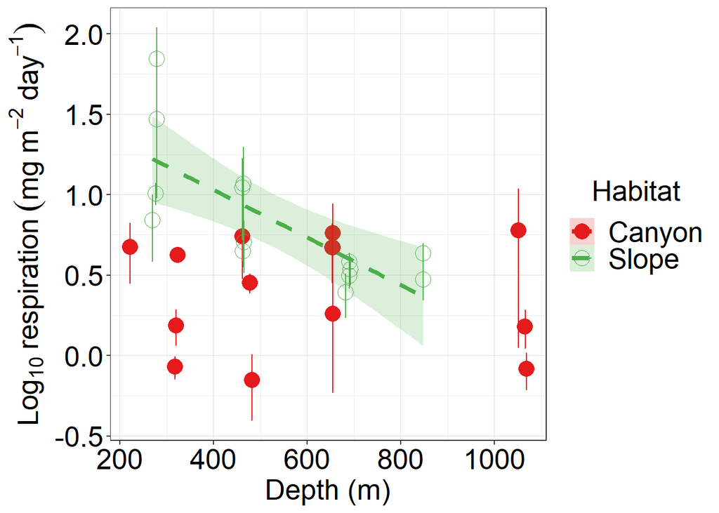

```r
(f5d <- ggplot(data=out,
       aes(x=Depth, y=log10(respirationW),
           ymin=log10(respirationW-respirationW.se), ymax=log10(respirationW+respirationW.se),
           shape=Habitat, colour=Habitat, fill=Habitat, linetype=Habitat))+
  geom_point(size=5, position="jitter")+
  stat_smooth(data=subset(out, Habitat=="Slope"), method="lm", formula=y~x, alpha=0.2, size=1.5)+
  geom_errorbar(linetype=1, position="jitter")+
  scale_colour_manual(values=c("#e41a1c", "#4daf4a"))+
  scale_fill_manual(values=c("#e41a1c", "#4daf4a"))+
  scale_linetype_manual(values=c(1,2))+
  scale_shape_manual(values=c(19,1))+
  labs(x="Depth (m)", y=expression(Log[10]~respiration~(mg~m^-2~day^-1)))+
  theme_bw() %+replace% large #%+replace% dark
)
```

```r
save(f5d, file="../rds/f5d.rds")
```

Respiration declined with depth on the slope.

## 3.3 Main test

```r
f <- gls(log10(respirationW) ~ Habitat+Depth+Cruise+Habitat:Depth+Habitat:Cruise+Depth:Cruise, data=out, method = "REML")
kable(summary(f)$tTable)
```

|  | Value | Std.Error | t-value | p-value |
| --- | --- | --- | --- | --- |
| (Intercept) | 0.4426297 | 0.3707226 | 1.1939647 | 0.2510325 |
| HabitatSlope | 0.8117452 | 0.3385281 | 2.3978664 | 0.0299495 |
| Depth | 0.0006348 | 0.0007365 | 0.8618912 | 0.4023163 |
| CruiseOR1_1102 | 0.2467757 | 0.4894108 | 0.5042302 | 0.6214251 |
| CruiseOR1_1114 | -0.3479982 | 0.4674511 | -0.7444590 | 0.4681024 |
| CruiseOR1_1126 | -0.4976221 | 0.4918669 | -1.0117007 | 0.3277233 |
| HabitatSlope:Depth | -0.0018134 | 0.0005103 | -3.5538239 | 0.0028865 |
| HabitatSlope:CruiseOR1_1102 | 0.7307977 | 0.3415775 | 2.1394785 | 0.0492465 |
| HabitatSlope:CruiseOR1_1114 | 0.7420602 | 0.3289644 | 2.2557461 | 0.0394500 |
| HabitatSlope:CruiseOR1_1126 | 0.7638286 | 0.3448696 | 2.2148330 | 0.0426692 |
| Depth:CruiseOR1_1102 | -0.0012039 | 0.0008532 | -1.4110307 | 0.1786390 |
| Depth:CruiseOR1_1114 | -0.0001151 | 0.0008155 | -0.1410965 | 0.8896711 |
| Depth:CruiseOR1_1126 | -0.0003013 | 0.0008184 | -0.3681946 | 0.7178724 |

```r
kable(anova(f))
```

|  | numDF | F-value | p-value |
| --- | --- | --- | --- |
| (Intercept) | 1 | 123.1705827 | 0.0000000 |
| Habitat | 1 | 14.8100799 | 0.0015791 |
| Depth | 1 | 5.9811981 | 0.0272735 |
| Cruise | 3 | 0.9451726 | 0.4436157 |
| Habitat:Depth | 1 | 8.3259345 | 0.0113234 |
| Habitat:Cruise | 3 | 2.3876246 | 0.1097212 |
| Depth:Cruise | 3 | 1.1768109 | 0.3516362 |

Significant habitat and depth effect, but there are also a significant interaction between habitat and depth.

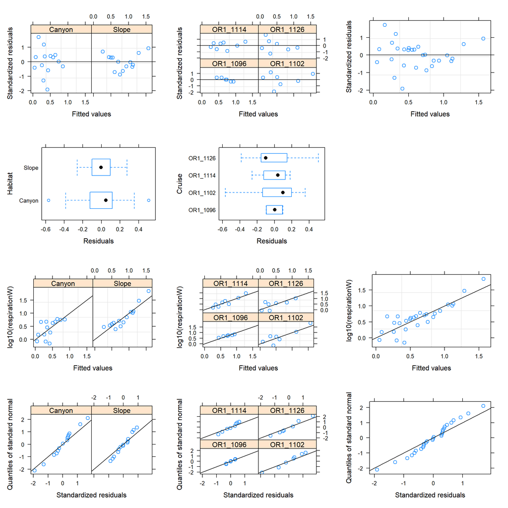

```r
# Dianotics plot
dianostic_plot(f, y = "log10(respirationW)")
```

## 3.4 Pairwise tests

```r
# In canyon
f <- gls(log10(respirationW) ~ Depth+Cruise+Depth:Cruise, data=subset(out, Habitat == "Canyon"), method = "REML")
kable(summary(f)$tTable)
```

|  | Value | Std.Error | t-value | p-value |
| --- | --- | --- | --- | --- |
| (Intercept) | 0.6340777 | 0.5942052 | 1.0671024 | 0.3269686 |
| Depth | 0.0002058 | 0.0012374 | 0.1663441 | 0.8733501 |
| CruiseOR1_1102 | -0.1463478 | 0.7592443 | -0.1927546 | 0.8535101 |
| CruiseOR1_1114 | -0.6654821 | 0.7609750 | -0.8745124 | 0.4154677 |
| CruiseOR1_1126 | -0.4060159 | 0.7985028 | -0.5084715 | 0.6292721 |
| Depth:CruiseOR1_1102 | -0.0004553 | 0.0014149 | -0.3217786 | 0.7585356 |
| Depth:CruiseOR1_1114 | 0.0005153 | 0.0014199 | 0.3628702 | 0.7291423 |
| Depth:CruiseOR1_1126 | -0.0002885 | 0.0014291 | -0.2018887 | 0.8466748 |

```r
kable(anova(f))
```

|  | numDF | F-value | p-value |
| --- | --- | --- | --- |
| (Intercept) | 1 | 16.0724605 | 0.0070460 |
| Depth | 1 | 0.0390030 | 0.8499635 |
| Cruise | 3 | 1.1749871 | 0.3946448 |
| Depth:Cruise | 3 | 0.3727289 | 0.7760743 |

```r
# On slope
f <- gls(log10(respirationW) ~ Depth+Cruise+Depth:Cruise, data=subset(out, Habitat == "Slope"), method = "REML")
kable(summary(f)$tTable)
```

|  | Value | Std.Error | t-value | p-value |
| --- | --- | --- | --- | --- |
| (Intercept) | 1.0391384 | 0.2398432 | 4.3325733 | 0.0049149 |
| Depth | -0.0007262 | 0.0004740 | -1.5318890 | 0.1764339 |
| CruiseOR1_1102 | 1.7626499 | 0.3458702 | 5.0962761 | 0.0022295 |
| CruiseOR1_1114 | 0.7906136 | 0.3116822 | 2.5366021 | 0.0442834 |
| CruiseOR1_1126 | 0.1278749 | 0.3113538 | 0.4107061 | 0.6955526 |
| Depth:CruiseOR1_1102 | -0.0028568 | 0.0006860 | -4.1643406 | 0.0059157 |
| Depth:CruiseOR1_1114 | -0.0008858 | 0.0005756 | -1.5388724 | 0.1747579 |
| Depth:CruiseOR1_1126 | -0.0001330 | 0.0005751 | -0.2312302 | 0.8248195 |

```r
kable(anova(f))
```

|  | numDF | F-value | p-value |
| --- | --- | --- | --- |
| (Intercept) | 1 | 491.082674 | 0.0000006 |
| Depth | 1 | 63.211054 | 0.0002106 |
| Cruise | 3 | 6.008792 | 0.0306984 |
| Depth:Cruise | 3 | 8.099292 | 0.0156727 |

```r
# GC1 and GS1
f <- gls(log10(respirationW) ~ Habitat, data=subset(out, Station=="GC1"|Station=="GS1"), method = "REML")
kable(summary(f)$tTable)
```

|  | Value | Std.Error | t-value | p-value |
| --- | --- | --- | --- | --- |
| (Intercept) | 0.3535803 | 0.2045155 | 1.728869 | 0.1345652 |
| HabitatSlope | 0.9371832 | 0.2892285 | 3.240286 | 0.0176805 |

```r
kable(anova(f))
```

|  | numDF | F-value | p-value |
| --- | --- | --- | --- |
| (Intercept) | 1 | 32.32236 | 0.0012772 |
| Habitat | 1 | 10.49945 | 0.0176805 |

```r
# GC2 and GS2
f <- gls(log10(respirationW) ~ Habitat, data=subset(out, Station=="GC2"|Station=="GS2"), method = "REML")
kable(summary(f)$tTable)
```

|  | Value | Std.Error | t-value | p-value |
| --- | --- | --- | --- | --- |
| (Intercept) | 0.3470795 | 0.1932827 | 1.795709 | 0.1324875 |
| HabitatSlope | 0.5187054 | 0.2556890 | 2.028658 | 0.0982792 |

```r
kable(anova(f))
```

|  | numDF | F-value | p-value |
| --- | --- | --- | --- |
| (Intercept) | 1 | 25.862133 | 0.0038167 |
| Habitat | 1 | 4.115451 | 0.0982792 |

```r
# GC3 and GS3
f <- gls(log10(respirationW) ~ Habitat, data=subset(out, Station=="GC3"|Station=="GS3"), method = "REML")
kable(summary(f)$tTable)
```

|  | Value | Std.Error | t-value | p-value |
| --- | --- | --- | --- | --- |
| (Intercept) | 0.5909104 | 0.0845812 | 6.9863082 | 0.000428 |
| HabitatSlope | -0.0895926 | 0.1196159 | -0.7490025 | 0.482176 |

```r
kable(anova(f))
```

|  | numDF | F-value | p-value |
| --- | --- | --- | --- |
| (Intercept) | 1 | 83.3775212 | 0.000097 |
| Habitat | 1 | 0.5610048 | 0.482176 |

```r
# GC4 and GS4
f <- gls(log10(respirationW) ~ Habitat, data=subset(out, Station=="GC4"|Station=="GS4"), method = "REML")
kable(summary(f)$tTable)
```

|  | Value | Std.Error | t-value | p-value |
| --- | --- | --- | --- | --- |
| (Intercept) | 0.2917451 | 0.2120180 | 1.3760392 | 0.2625388 |
| HabitatSlope | 0.2624836 | 0.3352299 | 0.7829959 | 0.4907531 |

```r
kable(anova(f))
```

|  | numDF | F-value | p-value |
| --- | --- | --- | --- |
| (Intercept) | 1 | 5.8359563 | 0.0945263 |
| Habitat | 1 | 0.6130825 | 0.4907531 |

Only significant depth effect on slope

# 4 Daily respiration in carbon per square meter

## 4.1 Linear regression with depth

```r
splitBy(~Habitat, out) %>% lapply(FUN=function(x)lm(log10(respirationC)~Depth, data=x) %>% summary)
```

```
## $Canyon
##
## Call:
## lm(formula = log10(respirationC) ~ Depth, data = x)
##
## Residuals:
##      Min       1Q   Median       3Q      Max
## -0.57000 -0.26310  0.09129  0.24223  0.52138
##
## Coefficients:
##               Estimate Std. Error t value Pr(>|t|)
## (Intercept) -6.666e-01  2.218e-01  -3.006    0.011 *
## Depth        9.931e-05  3.354e-04   0.296    0.772
## ---
## Signif. codes:  0 '***' 0.001 '**' 0.01 '*' 0.05 '.' 0.1 ' ' 1
##
## Residual standard error: 0.3479 on 12 degrees of freedom
## Multiple R-squared:  0.007254,   Adjusted R-squared:  -0.07547
## F-statistic: 0.08768 on 1 and 12 DF,  p-value: 0.7722
##
##
## $Slope
##
## Call:
## lm(formula = log10(respirationC) ~ Depth, data = x)
##
## Residuals:
##      Min       1Q   Median       3Q      Max
## -0.33299 -0.19352 -0.01032  0.11067  0.59905
##
## Coefficients:
##               Estimate Std. Error t value Pr(>|t|)
## (Intercept)  0.5424614  0.1943498   2.791  0.01631 *
## Depth       -0.0014632  0.0003429  -4.268  0.00109 **
## ---
## Signif. codes:  0 '***' 0.001 '**' 0.01 '*' 0.05 '.' 0.1 ' ' 1
##
## Residual standard error: 0.2607 on 12 degrees of freedom
## Multiple R-squared:  0.6028, Adjusted R-squared:  0.5697
## F-statistic: 18.21 on 1 and 12 DF,  p-value: 0.001093
```

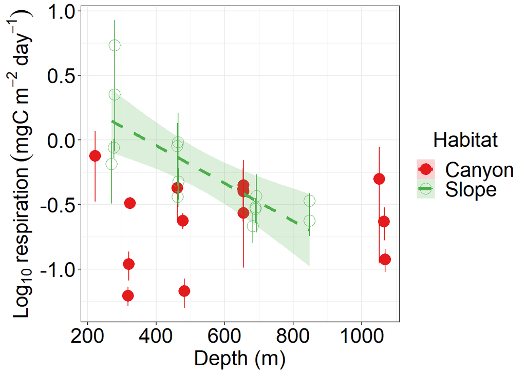

```r
ggplot(data=out,
       aes(x=Depth, y=log10(respirationC),
           ymin=log10(respirationC-respirationC.se), ymax=log10(respirationC+respirationC.se),
           shape=Habitat, colour=Habitat, fill=Habitat, linetype=Habitat))+
  geom_point(size=5, position="jitter")+
  stat_smooth(data=subset(out, Habitat=="Slope"), method="lm", formula=y~x, alpha=0.2, size=1.5)+
  geom_errorbar(linetype=1, position="jitter")+
  scale_colour_manual(values=c("#e41a1c", "#4daf4a"))+
  scale_fill_manual(values=c("#e41a1c", "#4daf4a"))+
  scale_linetype_manual(values=c(1,2))+
  scale_shape_manual(values=c(19,1))+
  labs(x="Depth (m)", y=expression(Log[10]~respiration~(mgC~m^-2~day^-1)))+
  theme_bw() %+replace% large #%+replace% dark
```

Respiration declined with depth on the slope.

# 5 Daily respiration in J per square meter

## 5.1 Linear regression with depth

```r
splitBy(~Habitat, out) %>% lapply(FUN=function(x)lm(log10(respirationJ)~Depth, data=x) %>% summary)
```

```
## $Canyon
##
## Call:
## lm(formula = log10(respirationJ) ~ Depth, data = x)
##
## Residuals:
##      Min       1Q   Median       3Q      Max
## -0.56697 -0.26244  0.07665  0.24891  0.51549
##
## Coefficients:
##              Estimate Std. Error t value Pr(>|t|)
## (Intercept) 1.002e+00  2.244e-01   4.465 0.000773 ***
## Depth       6.256e-05  3.393e-04   0.184 0.856800
## ---
## Signif. codes:  0 '***' 0.001 '**' 0.01 '*' 0.05 '.' 0.1 ' ' 1
##
## Residual standard error: 0.352 on 12 degrees of freedom
## Multiple R-squared:  0.002825,   Adjusted R-squared:  -0.08027
## F-statistic: 0.03399 on 1 and 12 DF,  p-value: 0.8568
##
##
## $Slope
##
## Call:
## lm(formula = log10(respirationJ) ~ Depth, data = x)
##
## Residuals:
##      Min       1Q   Median       3Q      Max
## -0.31646 -0.19497 -0.00758  0.10898  0.60030
##
## Coefficients:
##               Estimate Std. Error t value Pr(>|t|)
## (Intercept)  2.2050682  0.1936049  11.390 8.63e-08 ***
## Depth       -0.0014798  0.0003415  -4.333 0.000974 ***
## ---
## Signif. codes:  0 '***' 0.001 '**' 0.01 '*' 0.05 '.' 0.1 ' ' 1
##
## Residual standard error: 0.2597 on 12 degrees of freedom
## Multiple R-squared:   0.61,  Adjusted R-squared:  0.5775
## F-statistic: 18.77 on 1 and 12 DF,  p-value: 0.0009742
```

[figure not shown]

```r
ggplot(data=out,
       aes(x=Depth, y=log10(respirationJ),
           ymin=log10(respirationJ-respirationJ.se), ymax=log10(respirationJ+respirationJ.se),
           shape=Habitat, colour=Habitat, fill=Habitat, linetype=Habitat))+
  geom_point(size=5, position="jitter")+
  stat_smooth(data=subset(out, Habitat=="Slope"), method="lm", formula=y~x, alpha=0.2, size=1.5)+
  geom_errorbar(linetype=1, position="jitter")+
  scale_colour_manual(values=c("#e41a1c", "#4daf4a"))+
  scale_fill_manual(values=c("#e41a1c", "#4daf4a"))+
  scale_linetype_manual(values=c(1,2))+
  scale_shape_manual(values=c(19,1))+
  labs(x="Depth (m)", y=expression(Log[10]~respiration~(J~m^-2~yr^-1)))+
  theme_bw() %+replace% large #%+replace% dark
```

Respiration declined with depth on the slope.